# Présentation de l’outil Podcasts Tracker

2023-03-07

## Introduction

- Constat : il n’existe pas de moyens pour filtrer les résultats par durée sur Spotify
- Création d’un outil pour chercher des épisodes/émissions par durée
- Démonstration de l’outil

## Mise en place du projet

1. Utilisation de Spotify pour notre projet à l’aide du package Python Spotipy  
   Fonction principale que nous avons utilisé :

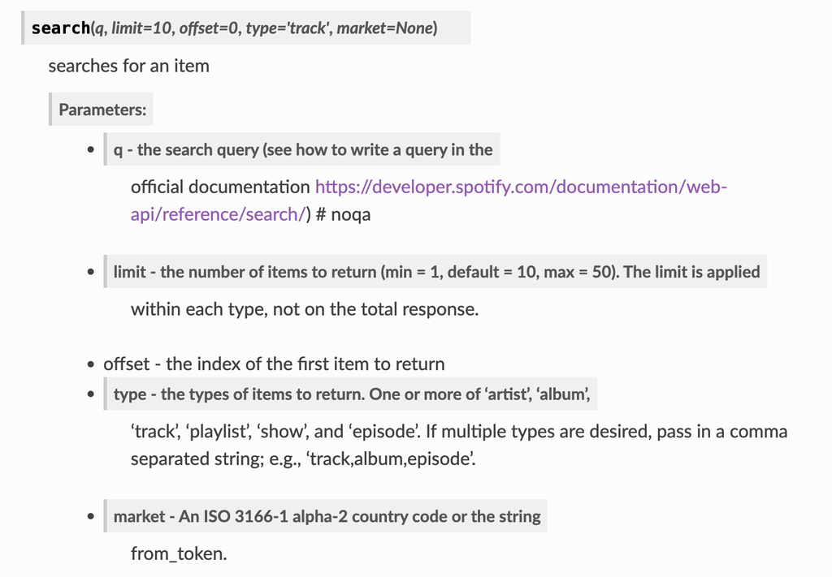

   NB : distinction entre émission et épisode, impossible de faire des recherches par durée même depuis l’API

## Mise en place du projet

1. Création d’un Bot Telegram pour envoyer les liens directement sur le téléphone de l’utilisateur

[figure not shown]

   - Récupération du Token afin de connecter le code Python au Bot Telegram

## Premier problème rencontré

- Documentation complexe sur l’API Telegram, manque de temps pour créer un bot complètement automatisé  
  —> Solution : inputs seront saisis depuis l’ordinateur et seuls les résultats seront envoyés sur Telegram

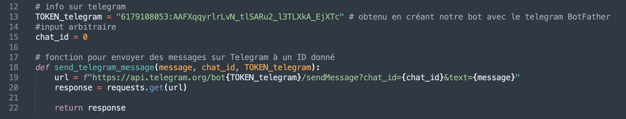

  - Fonction pour envoyer un message sur Telegram (send_message.py sur Github)

## Interface graphique

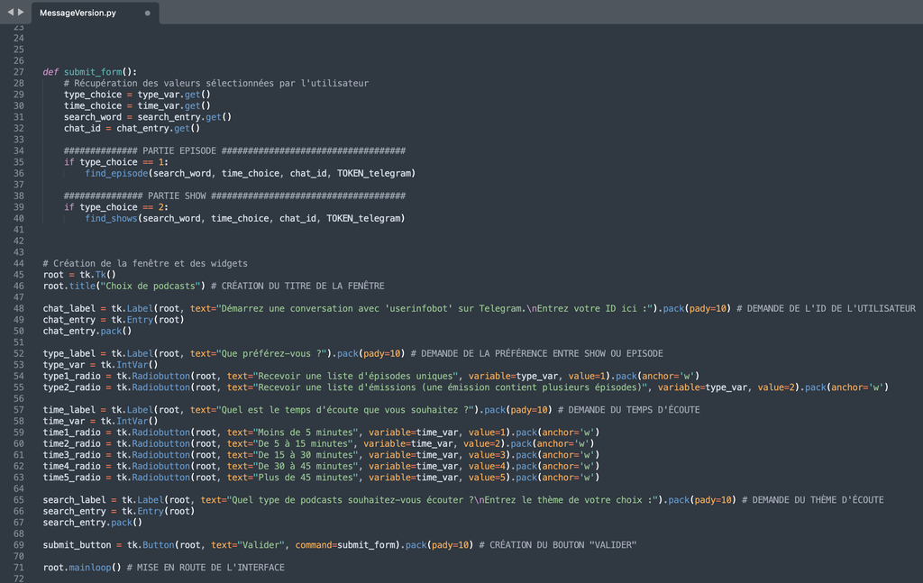

## Traitement des émissions

- Voir fichier Show_treatment sur Github
- Pas de variable indiquant la durée des émissions : il faut l’approximer !
- A partir des 50 premiers épisodes de l’émission
- Estimer bornes mini et maxi pour durée de chaque émission
- Eliminer les intervalles trop importants
- Uniformiser les intervalles restants
- Eviter les bugs

## Traitement des épisodes

- Episode_treatment sur Github :

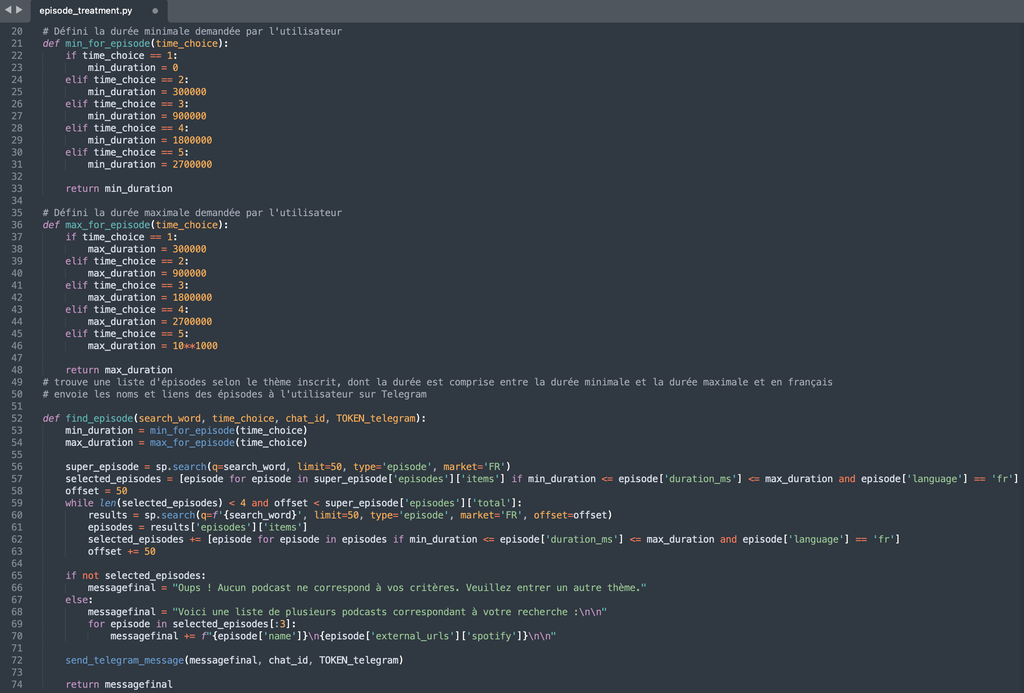

## Conclusion

- Pratique que chacun travaille sur une partie différente du code
- MAIS, cela complique l’assemblage des différentes parties
- Extensions possibles :
  - Bot Telegram complètement autonome
  - Donner plus de résultats sur un même sujet
  - Garder en mémoire chat_id
  - Créer .log des recherches et résultats de l’utilisateur